# R Training

**Create a multi-pane plot** using the function `par(mfrow=c())` before you call `plot()`:

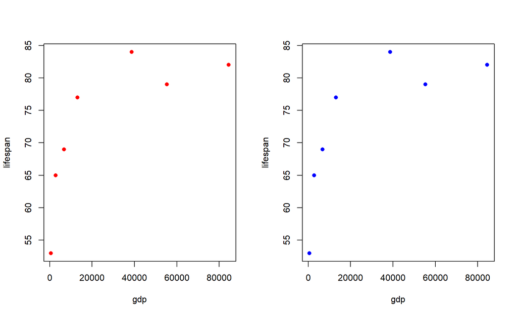

```r
par(mfrow=c(1,2))
plot(lifespan ~ gdp,col="red",pch=16)
plot(lifespan ~ gdp,col="blue",pch=16)
```

In this command, the two numbers in the vector used to define `mfrow` correspond to the number of rows and columns, respectively, on the entire plot. In this case, you have 1 row of plots with two columns.

Note that you will need to reset the number of panes when you are done with your multi-pane plot!

```r
par(mfrow=c(1,1))
```

**Plot dots and lines at once** using the input `type`:

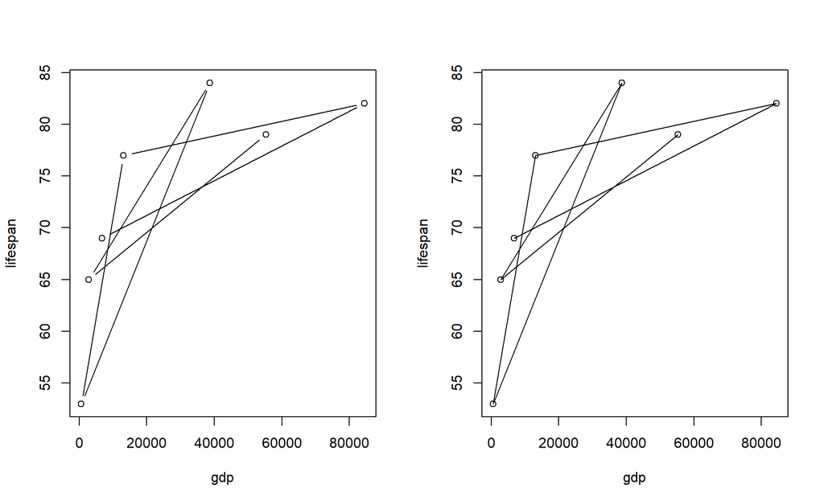

```r
par(mfrow=c(1,2))
plot(lifespan ~ gdp,type="b")
plot(lifespan ~ gdp,type="o")
```

```r
par(mfrow=c(1,1))
```

Note the two slightly different formats here.

**Use a logarithmic scale** for one or of your axes using the input `log`

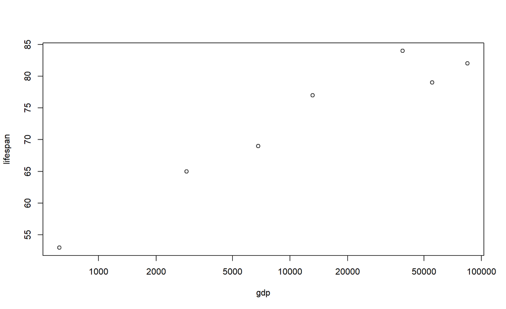

```r
plot(lifespan ~ gdp,log="x")
```

## Plotting with data frames

So far in this tutorial we have been using vectors to produce plots. This is nice for learning, but does not represent the real world very well. You will almost always be producing plots using dataframes.

Let’s turn these vectors into a dataframe:

```r
df <- data.frame(country,lifespan,gdp)
df
           country lifespan   gdp
1              USA       79 55335
2         Tanzania       65  2875
3            Japan       84 38674
4 Ctr. Africa Rep.       53   623
5            China       77 13102
6           Norway       82 84500
7            India       69  6807
```

To plot data within a dataframe, your `plot()` syntax changes slightly:

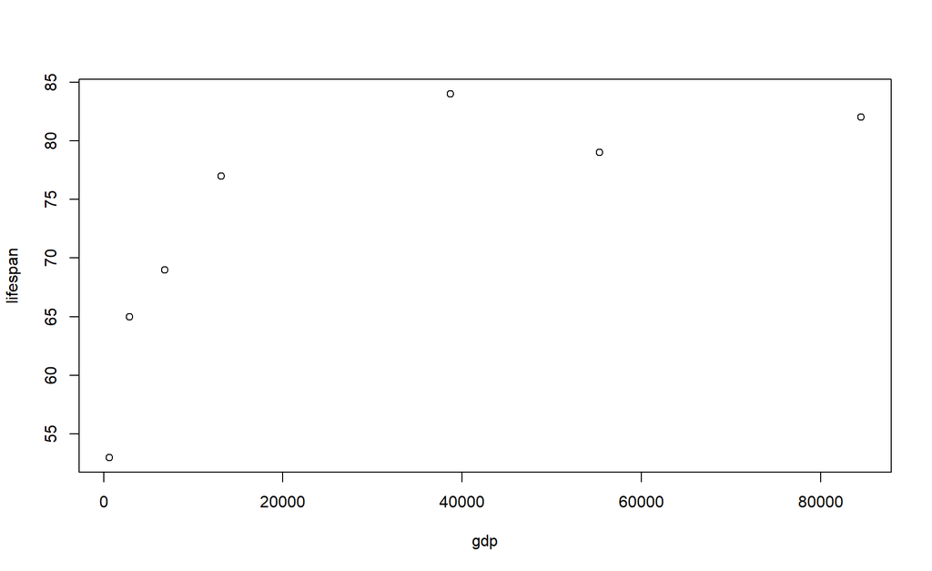

```r
plot(lifespan ~ gdp, data=df)
```

This syntax is saying this: using the dataframe named `df` as a source, plot column `lifespan` as a function of column `gdp`. The symbol `~` denotes *“as a function of”*. This frames `lifespan` as a dependent variable (y axis) that is affected by the independent variable (x axis), which in this case is `gdp`.

Another way to write this command is as follows:

```r
plot(df$lifespan ~ df$gdp)
```

In this command, as you learned in the dataframes module, the `$` symbol is saying, “give me the column in `df` named `lifespan`”. It is a handy way of referring to a column within a dataframe by name.

#### Exercises

**The economics of health**

**1.** Using the data above, produce a bar plot that shows the GDP for each country.

**2.** Use the `df` dataframe you built above to produce a bar plot that shows life expectancy for each country.

**3.** Use the `df` dataframe to produce a jumbled line plot of life expectancy as a function of GDP. Reference the `plot()` documentation to figure out how to change the thickness of the line.

**Shoe ~ height correlation**

**4.** Create a vector of the names of 5 people who are sitting near you. Call it `people`.

**5.** Create a vector of those same 5 people’s shoe sizes (in the same order!). Call it `shoe_size`.

**6.** Create another vector of those same 5 people’s height. Call it `height`.

**7.** Create another vector of those same 5 people’s sex. Call it `sex`.

**8.** Make a scatterplot of height and shoe size. Is there a correlation?

**9.** Look up help for `boxplot`. Make a `boxplot`.

**10.** Make a dataframe named `df`. It should contain columns of all the vectors created so far.

**11.** Make a side by side `boxplot` with shoe sizes of males vs females.

**12.** Try to find documentation for making a “histogram” (hint: use text autocomplete).

**13.** Make a histogram of people’s height.

**Make your plot beautiful**

**14.** Produce a *beautifully* formatted plot that incorporates **all** of the customization inputs explained above into a multi-paned plot. Use any dataset from this module that you wish.

#### Other Resources

- [R color palette](http://www.stat.columbia.edu/~tzheng/files/Rcolor.pdf)
- [The R Graph Gallery](https://www.r-graph-gallery.com/)